# 01 线性回归

2026-9-9

课程代码均在如下 GitHub 仓库开源：https://github.com/GHe0000/xmu_machine_learning

项目自动生成网页地址：https://ghe0000.github.io/xmu_machine_learning

## 目录

- 作业要求
- 背景补充：最小二乘、梯度下降
  - 最小二乘
  - 解析法
  - 梯度下降
- 数据预处理：数据生成，数据集划分
  - 计算准备
  - 生成数据集
- 使用多项式基底
  - 特征工程
  - 损失函数定义
  - 模型训练
  - 超参优化
  - 幂函数基底梯度下降失效的分析
  - 正交多项式基底
  - 模型评估和最优模型选择
- 使用正弦函数基底
  - 特征工程
  - 模型构建与训练、超参优化
  - 模型评估和最优模型选择
- 混合基底
  - 特征工程
  - 模型构建与训练、超参优化
  - 模型评估
- 模型比较
- 结论
- 参考资料以及 AI 使用声明
- 致谢
- 附一：问题
- 附二：其他学习心得

## 作业要求

利用函数 $y(x) = 2x + \sin 26 x + \xi$ 构造数据集完成回归任务。其中 $ x \in [-1,1]$, $\xi$ 为 $[-1,1]$ 区间均匀分布随机数，幅度自己指定。数据集大小也自己指定即可。

分别利用多项式和 $\sin$（或者 $\cos$) 作为特征函数完成回归任务。并比较两者的性能。优化算法选择梯度下降。

要求：1）作业完整。2）机器学习流程完整：1. 生成数据集；2. Feature Mapping ($X$ 矩阵）； 3. 特征规范化； 4. 正则化；5. 训练调优； 6. 模型比较; 7 结论.

## 背景补充：最小二乘、梯度下降

### 最小二乘

假设系统 $y(x)$ 可以由基函数 $\phi_1(x),\dots$ 进行展开，即系统可以写为：

$$ y(x) = \sum_i \theta_i \phi_i (x) $$

其中展开系统 $\theta_1,\dots$ 待定，需要我们进行求解. 我们的目标是求解出最优的 $\{\theta_i\}$. 上述方程写成矩阵的形式：

$$y = X w $$

其中数据矩阵为

$$ X = \begin{bmatrix} 1,\phi_1(x_1) & \phi_2(x_1) & \cdots & \phi_n(x_1)\\ 1,\phi_1(x_2) & \phi_2(x_2) & \cdots & \phi_n(x_2)\\ 1,\vdots & \vdots & \ddots & \vdots\\ 1,\phi_1(x_m) & \phi_2(x_m) & \cdots & \phi_n(x_m) \end{bmatrix} $$

参数权重矩阵为 $w = [\theta_1, \theta_2, \dots, \theta_D]^T$.

定义 MSE：

$$ J(w) = \frac{1}{n} (y_{pred}-y)^T (y_{pred}-y) $$

MSE 越小，则模型与数据越吻合，我们认为模型的效果越好. 根据前一年课程的内容，模型可能会出现**过拟合**（参考个人科编作业，ref:https://spi.ghe0000.pp.ua/web/12%E7%BA%BF%E6%80%A7%E5%9B%9E%E5%BD%92.html） 因此我们需要使用一定的**正则化**方法来尽量防止过拟合. 这里我们使用 **L2 正则化**，因此，损失函数定义为：

$$L(w) = \frac{1}{2} J(w) + \frac{\lambda}{2} \sum_{j=1}^n w_j^2$$

其中第二项为 L2 正则化项.

### 解析法

此时我们需要求解参数矩阵 $w$ 使得模型最优，通过对损失函数 $J(w)$ 关于 $w$ 求偏导并令其等于零矩阵 $\nabla_w J(w) = \mathbf{0}$：

$$\nabla_w J(w) = \frac{1}{N} X^T (X w - y) + \lambda w = 0$$

我们得到最优参数矩阵 $w^*$ 的表达式：

$$w^* = \left( X^T X + N \lambda I \right)^{-1} X^T y$$

### 梯度下降

当特征维度较大（$n$ 较大）或数据量巨大时，直接计算解析解 $w^* = \left( X^T X + N \lambda I \right)^{-1} X^T y$ 会涉及复杂的高维矩阵求逆. 此时，我们可以采用梯度下降法这一数值优化算法来迭代逼近最优解.

梯度下降的基本思想是：从随机初始化的参数 $w^{(0)}$ 开始，沿着损失函数 $L(w)$ 的负梯度方向（下降最快的方向）按一定步长（学习率 $\eta$）逐步更新参数，直至损失函数收敛到极小值点 .

根据前面推导出的损失函数 $L(w)$ 关于 $w$ 的偏导数（梯度）：

$$\nabla_w L(w) = \frac{1}{N} X^T (X w - y) + \lambda w$$

设 $\eta > 0$ 为学习率. $t+1$ 次迭代的参数更新公式为：

$$w^{(t+1)} = w^{(t)} - \eta \cdot \nabla_w L(w^{(t)})$$

带入，得到具体更新迭代式：$$w^{(t+1)} = \left( 1 - \eta \lambda \right) w^{(t)} - \frac{\eta}{N} X^T \left( X w^{(t)} - y \right)$$

经过不断迭代，则 $w^{(t)}$ 会趋向于前面得到的直接得到的解析公式的解，$ w^{(t)} \to w^* $

## 数据预处理：数据生成，数据集划分

### 计算准备

导入需要的库，并针对 Jupyter Notebook 进行一些设置.

```python
import numpy as np # 数值计算库
import numba as nb # 引入 jit 来加速函数（如果需要）
import sympy as sym # 符号计算库
import matplotlib as mpl
import matplotlib.pyplot as plt # 图像绘制
from matplotlib.backends.backend_agg import FigureCanvasAgg # 设置图像后端用
import ipywidgets as ipw # 交互控件
from IPython.display import display, Math, Latex # 打印数学公式
import time
import tracemalloc

from io import BytesIO
import matplotlib.animation as animation # 创建动画
from IPython.display import HTML # 动画嵌入
import scipy

# 使用 mathjax 来在 jupyter notebook 显示数学公式
sym.init_printing(use_latex='mathjax')

# 设置 matplotlib 绘制的图像嵌入到 jupyter notebook 的方式
%matplotlib widget

# 一个工具函数，可以让静态图片不经过 widget 直接嵌入 Jupyter notebook
# 这样图片可以直接存到 nb 文件里，而不是需要运行才能显示（类似 inline）
def display_inline(fig):
    fig.set_canvas(FigureCanvasAgg(fig))
    display(fig)
    plt.close(fig) # 释放 fig，减小资源消耗

# 一个工具函数，用于在 Jupyter 中快速实现公式和字符串混合输出
def display_math(*args):
    parts = []
    for a in args:
        if isinstance(a, str):
            parts.append(a)
        else:
            parts.append(sym.latex(a))
    display(Math("".join(parts)))

# 设置 matplotlib 使用的字体，避免出现中文问题
plt.rcParams.update({
    # 字体
    "font.family": ["SimSun", "Times New Roman"],
    "font.size": 14,
    "mathtext.fontset": "cm",
    "axes.unicode_minus": False,

    # 字号
    "axes.titlesize": 14,
    "axes.labelsize": 14,
    "xtick.labelsize": 14,
    "ytick.labelsize": 14,
    "legend.fontsize": 14,
    "figure.titlesize": 14,
})

# 设置种子，保证可重复性
np.random.seed(3407)
```

### 生成数据集

根据题目要求，$y(x) = 2x + \sin 26 x + \xi$ 构造数据集，其中 $ x \in [-1,1]$, $\xi$ 为 $[-1,1]$ 区间均匀分布随机数，噪声幅度定为 $0.2$. 随机采样 300 个点，并绘制在图中.

```python
N = 300 # 数据集大小
noise_amplitude = 0.2 # 噪声幅度
x_data = np.random.uniform(-1, 1, N)
xi = np.random.uniform(-1, 1, N) * noise_amplitude
y_data = 2 * x_data + np.sin(26 * x_data) + xi

x_true = np.linspace(-1, 1, 1000)
y_true = 2 * x_true + np.sin(26 * x_true)
```

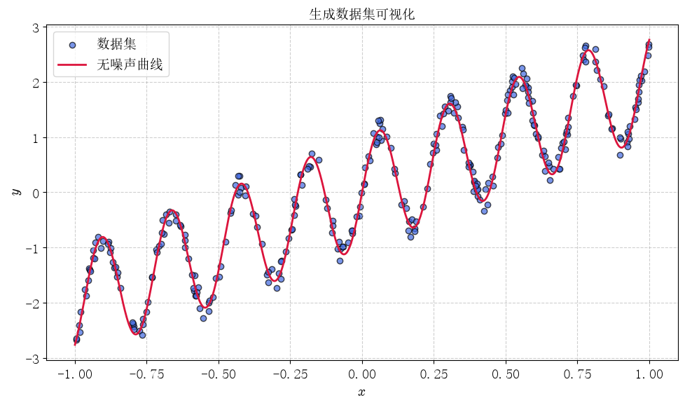

```python
fig, ax = plt.subplots(figsize=(10, 6))

ax.scatter(
    x_data, y_data, color="royalblue", alpha=0.7, edgecolors="k", label="数据集"
)

ax.plot(
    x_true,
    y_true,
    color="crimson",
    linewidth=2,
    label="无噪声曲线",
)

ax.set_title("生成数据集可视化")
ax.set_xlabel(r"$x$")
ax.set_ylabel(r"$y$")
ax.grid(True, linestyle="--", alpha=0.6)
ax.legend()

fig.tight_layout()
display_inline(fig)
```

300 个数据，按 8:2 划分训练集和测试集，并绘制划分完成的训练集和测试集：

```python
rng = np.random.default_rng(42)
indices = rng.permutation(N)
train_size = int(N * 0.8)
train_idx = indices[:train_size]
test_idx = indices[train_size:]
x_train = x_data[train_idx]
y_train = y_data[train_idx]
x_test = x_data[test_idx]
y_test = y_data[test_idx]

print(f"训练集大小：{x_train.shape}")
print(f"测试集大小：{x_test.shape}")
```

```
训练集大小：(240,)
测试集大小：(60,)
```

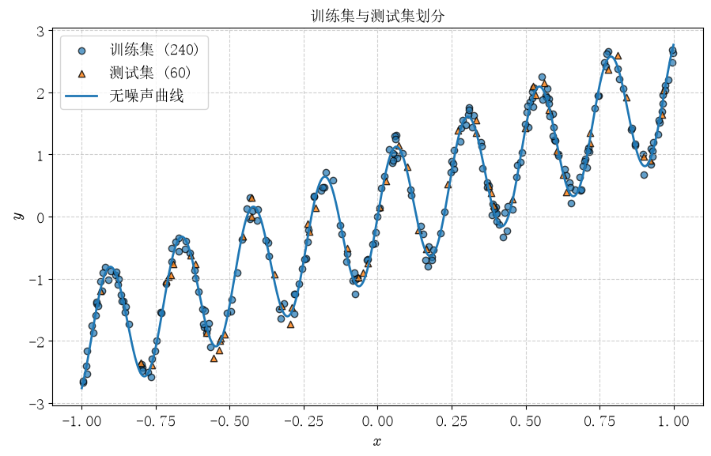

```python
fig, ax = plt.subplots(figsize=(10, 6))
# 训练集
ax.scatter(
    x_train,
    y_train,
    alpha=0.7,
    edgecolors="k",
    label=f"训练集 ({len(x_train)})",
)

# 测试集
ax.scatter(
    x_test,
    y_test,
    alpha=0.8,
    edgecolors="k",
    marker="^",
    label=f"测试集 ({len(x_test)})",
)

# 无噪声真实曲线
ax.plot(
    x_true,
    y_true,
    linewidth=2,
    label="无噪声曲线",
)

ax.set_title("训练集与测试集划分")
ax.set_xlabel(r"$x$")
ax.set_ylabel(r"$y$")
ax.grid(True, linestyle="--", alpha=0.6)
ax.legend()

fig.tight_layout()
display_inline(fig)
```

## 使用多项式基底

首先我们使用多项式基底，也就是选取 $x,x^2,x^3,\dots$ 作为函数基底. 这里我们使用**梯度下降**法进行训练. 根据背景介绍，系统有如下超参数：

- 多项式阶数：$n_{deg}$
- 系统学习率：$\eta$
- L2 正则化系数：$\lambda$

以及系统训练轮数 $n_{epoch}$. 后续我们会对其中超参设定进行讨论.

### 特征工程

首先，根据前文要求，我们先使用 Python + 多项式基底构造出数据矩阵 $X$（先认为设定多项式阶数 $n_{deg}=10$）：

```python
n_deg = 10

phi_map = lambda x: list(map(lambda k: x**k, range(n_deg+1)))
X_train = np.array(list(map(phi_map, x_train)))
X_test = np.array(list(map(phi_map, x_test)))
```

检查一下形状

```python
X_train.shape
```

$\displaystyle \left( 240, \ 11\right)$

之后我们需要进行**特征规范化**，这里我们对特征进行标准化，防止不同特征之间分布差异过大，导致不同特征的梯度差异过大，使得只能训练某几个特定参数

具体而言，特征标准化的操作是：

$$ x^{(i)}_{norm} = \frac{x^{(i)}-\mu}{\sigma} $$

其中 $x^{(i)}$ 为某数据特征的第 $i$ 个值. $\mu$ 为该列的平均值，$\sigma$ 是该列的标准差.

```python
mean = X_train[:, 1:].mean(axis=0)
std = X_train[:, 1:].std(axis=0)
std[std < 1e-12] = 1.0

X_train[:, 1:] = (X_train[:, 1:] - mean) / std
X_test[:, 1:] = (X_test[:, 1:] - mean) / std
```

同时，我们顺便初始化一下权重参数：

```python
w = np.random.normal(loc=0.0, scale=0.1, size=n_deg+1)
```

### 损失函数定义

下面我们进行损失函数定义，我们使用 MSE + L2 正则化，正则化系数 $\lambda$ 暂取 $0.1$.

```python
@nb.njit()
def mse_function(y_pred, y):
    m = y.size
    error = y_pred - y
    return 0.5*(error.T @ error) / m

@nb.njit()
def loss_function(y_pred, y, w, lam=0.1):
    mse_loss = mse_function(y_pred, y)
    l2_loss = 0.5 * (w.T @ w)
    return mse_loss + lam * l2_loss
```

### 模型训练

对于每一论，我们需要计算出梯度，根据公式：

$$\nabla_w L(w) = \frac{1}{N} X^T (X w - y) + \lambda w$$

从而得到每一轮的梯度计算函数：

```python
@nb.njit()
def gradient(X, y, w, lam):
    m = y.size
    grad = X.T @ (X @ w - y) / m + lam * w.copy()
    return grad
```

根据梯度下降的流程，我们自然可以得到训练过程：

```python
def train(X_train, y_train, X_test, y_test, w, epochs, lr, lam):
    loss_history = np.zeros(epochs + 1)
    train_mse_history = np.zeros(epochs + 1)
    test_mse_history = np.zeros(epochs + 1)
    y_train_pred = X_train @ w
    y_test_pred = X_test @ w
    loss_history[0] = loss_function(y_train_pred, y_train, w, lam)
    train_mse_history[0] = mse_function(y_train_pred, y_train)
    test_mse_history[0] = mse_function(y_test_pred, y_test)

    for epoch in range(1, epochs + 1):
        grad = gradient(X_train, y_train, w, lam)
        w -= lr * grad
        y_train_pred = X_train @ w
        y_test_pred = X_test @ w
        loss_history[epoch] = loss_function(y_train_pred, y_train, w, lam)
        train_mse_history[epoch] = mse_function(y_train_pred, y_train)
        test_mse_history[epoch] = mse_function(y_test_pred, y_test)
        print(f"\rTraining: {epoch}/{epochs}", end="", flush=True)
    print()
    return w, loss_history, train_mse_history, test_mse_history
```

设定超参 $n_{deg}=10$，学习率 $\eta=0.1$，L2 正则化系数 $\lambda=0.1$，训练轮数 $N=1000$. 绘制系统训练 Loss 和 MSE

```python
# 绘图函数
def plot_training_history(loss_history, train_mse_history, test_mse_history, title_suffix=""):
    epochs = np.arange(len(loss_history))

    # ------------------------------
    # Loss
    # ------------------------------
    fig_loss, ax = plt.subplots(figsize=(10, 6))

    ax.plot(epochs, loss_history, color="crimson", linewidth=2, label="训练 Loss")

    loss_final = loss_history[-1]
    ax.axhline(loss_final, color="crimson", linestyle="--", linewidth=1.5, alpha=0.8)
    ax.text(
        0.6, loss_final,
        f"渐进值 = {loss_final:.4g}",
        transform=ax.get_yaxis_transform(),
        ha="left",
        va="bottom",
        color="crimson",
    )

    ax.set_title("训练 Loss" + title_suffix)
    ax.set_xlabel("Epoch")
    ax.set_ylabel("Loss")
    ax.grid(True, linestyle="--", alpha=0.6)
    ax.legend()

    fig_loss.tight_layout()

    # ------------------------------
    # MSE
    # ------------------------------
    fig_mse, ax = plt.subplots(figsize=(10, 6))

    ax.plot(epochs, train_mse_history, color="royalblue", linewidth=2, label="训练集 MSE")
    ax.plot(epochs, test_mse_history, color="crimson", linewidth=2, label="测试集 MSE")

    train_final = train_mse_history[-1]
    test_final = test_mse_history[-1]

    ax.axhline(train_final, color="royalblue", linestyle="--", linewidth=1.5, alpha=0.8)
    ax.axhline(test_final, color="crimson", linestyle="--", linewidth=1.5, alpha=0.8)

    ax.text(
        0.6, train_final,
        f"训练集渐进值 = {train_final:.4g}",
        transform=ax.get_yaxis_transform(),
        ha="left",
        va="bottom",
        color="royalblue",
    )

    ax.text(
        0.6, test_final,
        f"测试集渐进值 = {test_final:.4g}",
        transform=ax.get_yaxis_transform(),
        ha="left",
        va="top",
        color="crimson",
    )

    ax.set_title("训练集与测试集 MSE" + title_suffix)
    ax.set_xlabel("Epoch")
    ax.set_ylabel("MSE")
    ax.grid(True, linestyle="--", alpha=0.6)
    ax.legend()

    fig_mse.tight_layout()

    return fig_loss, fig_mse
```

```python
lr = 0.1
lam = 0.1
n_epochs = 1000

w, loss_history, train_mse_history, test_mse_history = train(
    X_train, y_train, X_test, y_test, w, n_epochs, lr, lam
)
```

```
Training: 1000/1000
```

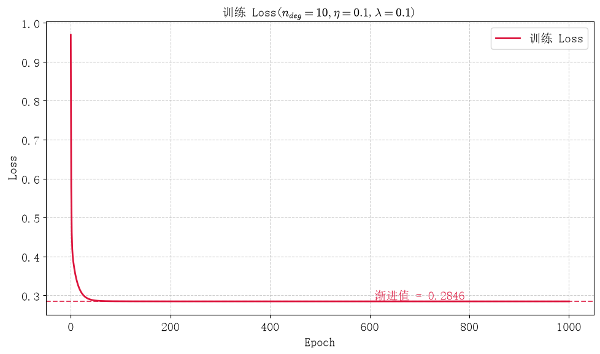

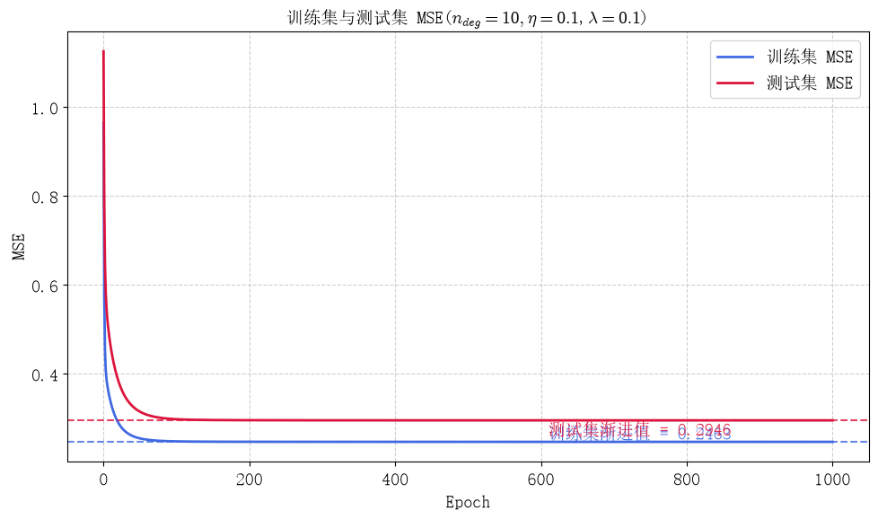

```python
fig_loss, fig_mse = plot_training_history(
    loss_history,
    train_mse_history,
    test_mse_history,
    r"($n_{deg}=10,\eta={0.1}$,${\lambda=0.1}$)"
)
display_inline(fig_loss)
display_inline(fig_mse)
```

可以看我们的 Loss 和训练 MSE，测试 MSE 均下降并到一个稳定程度. 说明我们的学习率和训练轮数足够，没有出现欠学习.

取最优模型，观察拟合后的曲线

```python
def plot_fitting_result(w, mean, std, title_suffix=""):
    n_deg = len(w) - 1

    X_true = np.array(
        list(map(lambda x: list(map(lambda k: x**k, range(n_deg + 1))), x_true))
    )

    X_true[:, 1:] = (X_true[:, 1:] - mean) / std
    y_pred = X_true @ w

    fig, ax = plt.subplots(figsize=(10, 6))
    ax.scatter(
        x_train, y_train,
        color="royalblue", alpha=0.7, edgecolors="k",
        label="训练集"
    )

    # 测试集
    ax.scatter(
        x_test, y_test,
        color="darkorange", alpha=0.7, edgecolors="k",
        label="测试集"
    )

    # 原始真实曲线
    ax.plot(
        x_true, y_true,
        color="crimson", linestyle="--", linewidth=2,
        label="原始曲线"
    )

    # 训练得到的曲线
    ax.plot(
        x_true, y_pred,
        color="forestgreen", linewidth=2,
        label="训练曲线"
    )

    ax.set_title("模型拟合结果" + title_suffix)
    ax.set_xlabel(r"$x$")
    ax.set_ylabel(r"$y$")
    ax.grid(True, linestyle="--", alpha=0.6)
    ax.legend()

    fig.tight_layout()

    return fig
```

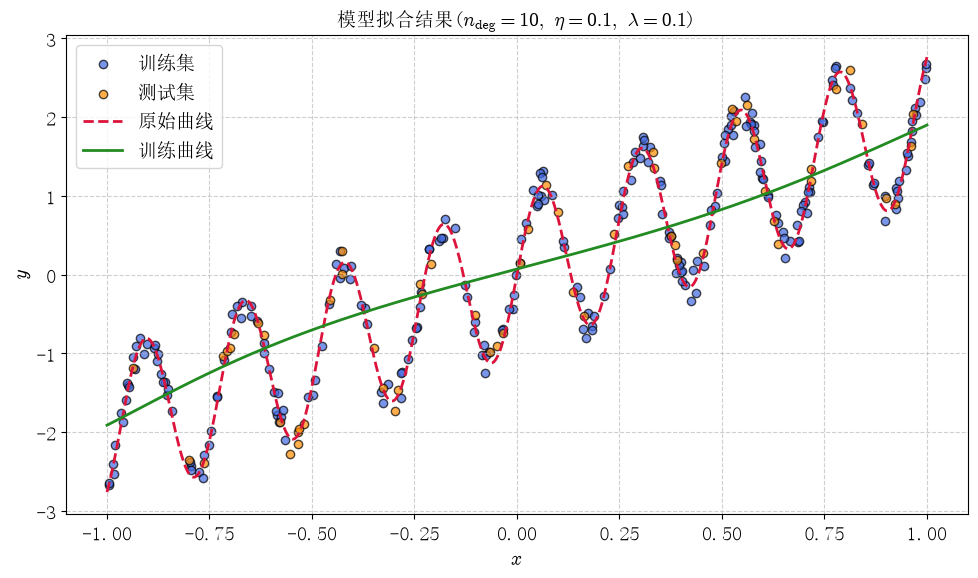

```python
fig = plot_fitting_result(
    w,mean,std,
    r"($n_{\mathrm{deg}}=10,\ \eta=0.1,\ \lambda=0.1$)"
)

display_inline(fig)
```

拟合效果并不好，或者说拟合效果很差，模型只抓住了主要的正相关趋势，而对于震荡的趋势，则完全没有学习到. 这可能是由于参数设置不合理导致的.

下面我们来改变超参，观察原因.

### 超参优化

从曲线中，我们可以观察到，模型出现了欠拟合，因此，有几种可能：

- L2 正则化过大
- 学习率过大
- 模型自身表达能力不够强（多项式阶数不够大）

我们先简单地取 L2 正则化系数 $\lambda-0$. 观察拟合情况。

```
Training: 1000/1000
```

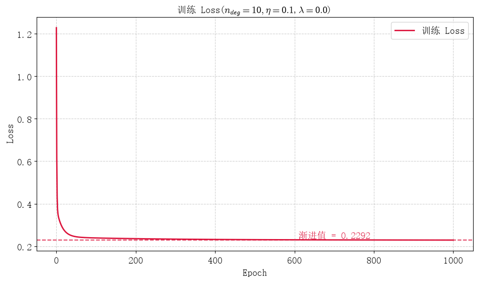

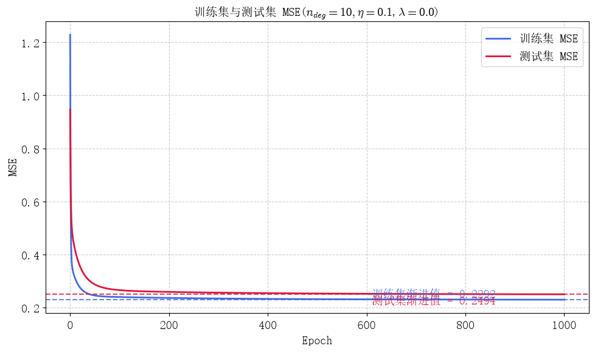

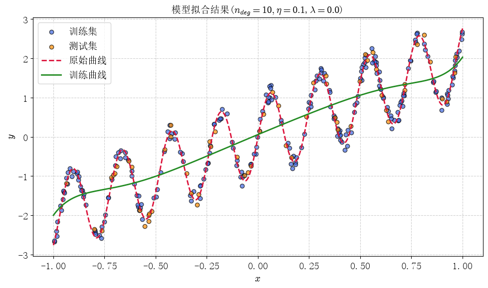

```python
lr = 0.1
lam = 0.0
n_epochs = 1000
n_deg = 10

phi_map = lambda x: list(map(lambda k: x**k, range(n_deg+1)))
X_train = np.array(list(map(phi_map, x_train)))
X_test = np.array(list(map(phi_map, x_test)))

mean = X_train[:, 1:].mean(axis=0)
std = X_train[:, 1:].std(axis=0)
std[std < 1e-12] = 1.0

X_train[:, 1:] = (X_train[:, 1:] - mean) / std
X_test[:, 1:] = (X_test[:, 1:] - mean) / std

w = np.random.normal(loc=0.0, scale=0.1, size=n_deg+1)

w, loss_history, train_mse_history, test_mse_history = train(
    X_train, y_train, X_test, y_test, w, n_epochs, lr, lam
)

fig_loss, fig_mse = plot_training_history(
    loss_history,
    train_mse_history,
    test_mse_history,
    r"($n_{deg}=10,\eta=0.1$,$\lambda=0.0$)"
)
display_inline(fig_loss)
display_inline(fig_mse)

fig = plot_fitting_result(
    w,mean,std,
    r"($n_{deg}=10,\eta=0.1$,$\lambda=0.0$)"
)

display_inline(fig)
```

可见，即使 L2 正则化设为 $0$，系统仍旧没有抓住振荡趋势，因此不是 L2 导致的欠拟合.

下面我们考虑学习率的影响，固定训练轮数，逐渐减小学习率，观察 Loss 曲线和模型拟合结果.

为了防止 "Early Stop" 造成的欠学习，我们增大训练轮数，取 $10000$.

```python
def compare_learning_rates(lrs, n_deg, lam, n_epochs, title_suffix=""):
    results = {}
    colors = plt.cm.tab10(np.linspace(0, 1, len(lrs)))
    rng = np.random.default_rng(42)

    phi_map = lambda x: list(map(lambda k: x**k, range(n_deg + 1)))

    X_train = np.array(list(map(phi_map, x_train)))
    X_test = np.array(list(map(phi_map, x_test)))
    X_true = np.array(list(map(phi_map, x_true)))

    mean = X_train[:, 1:].mean(axis=0)
    std = X_train[:, 1:].std(axis=0)
    std[std < 1e-12] = 1.0

    X_train[:, 1:] = (X_train[:, 1:] - mean) / std
    X_test[:, 1:] = (X_test[:, 1:] - mean) / std
    X_true[:, 1:] = (X_true[:, 1:] - mean) / std

    for lr in lrs:
        print(f"lr = {lr:g}")
        w = rng.normal(0, 0.1, n_deg + 1)

        w, loss_history, train_mse_history, test_mse_history = train(
            X_train, y_train, X_test, y_test, w, n_epochs, lr, lam
        )

        print(
            f"训练集最优 MSE：{np.nanmin(train_mse_history):.4g}, "
            f"测试集最优 MSE：{np.nanmin(test_mse_history):.4g}"
        )

        results[lr] = {
            "w": w,
            "loss": loss_history,
            "train_mse": train_mse_history,
            "test_mse": test_mse_history,
            "y_pred": X_true @ w,
        }
    fig_loss, ax = plt.subplots(figsize=(10, 6))

    for color, lr in zip(colors, lrs):
        epochs = np.arange(len(results[lr]["loss"]))

        ax.plot(
            epochs,
            results[lr]["loss"],
            color=color,
            linewidth=2,
            label=rf"$\eta={lr:g}$",
        )

    ax.set_title("不同学习率的训练 Loss" + title_suffix)
    ax.set_xlabel("Epoch")
    ax.set_ylabel("Loss")
    ax.grid(True, linestyle="--", alpha=0.6)
    ax.legend()

    fig_loss.tight_layout()
    fig_fit, ax = plt.subplots(figsize=(10, 6))

    ax.scatter(
        x_train, y_train,
        color="royalblue", alpha=0.5, edgecolors="k",
        label="训练集",
    )

    ax.scatter(
        x_test, y_test,
        color="darkorange", alpha=0.7, edgecolors="k",
        label="测试集",
    )

    ax.plot(
        x_true, y_true,
        color="black", linestyle="--", linewidth=2,
        label="原始曲线",
    )

    for color, lr in zip(colors, lrs):
        ax.plot(
            x_true,
            results[lr]["y_pred"],
            color=color,
            linewidth=2,
            label=rf"$\eta={lr:g}$",
        )

    ax.set_title("不同学习率的拟合结果" + title_suffix)
    ax.set_xlabel(r"$x$")
    ax.set_ylabel(r"$y$")
    ax.grid(True, linestyle="--", alpha=0.6)
    ax.legend()

    fig_fit.tight_layout()

    return fig_loss, fig_fit, results
```

```
lr = 0.1
Training: 10000/10000
训练集最优 MSE：0.2252, 测试集最优 MSE：0.2485
lr = 0.01
Training: 10000/10000
训练集最优 MSE：0.2293, 测试集最优 MSE：0.2497
lr = 0.001
Training: 10000/10000
训练集最优 MSE：0.239, 测试集最优 MSE：0.2653
lr = 0.0001
Training: 10000/10000
训练集最优 MSE：0.3084, 测试集最优 MSE：0.4008
```

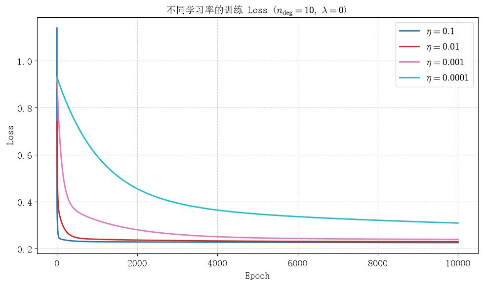

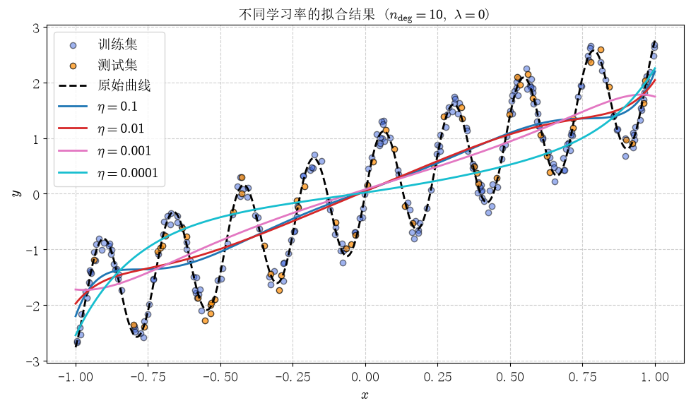

```python
lrs = [0.1, 0.01, 0.001, 0.0001]

fig_loss, fig_fit, results = compare_learning_rates(
    lrs,
    n_deg=10,
    lam=0.0,
    n_epochs=10000,
    title_suffix=r" ($n_{\mathrm{deg}}=10,\ \lambda=0$)",
)

display_inline(fig_loss)
display_inline(fig_fit)
```

可见，即使我们把 $n_{epoch}$ 取到 $10^4$ 且减小 $\eta$，系统欠学习程度更严重，因此系统的欠学习并不是由于学习率太大导致的.

那么我们来尝试增加多项式阶数，我们批量计算，取 $n_{deg}=10,50,100,200,300$ 观测 Loss 曲线和拟合结果

```python
def compare_degrees(degrees, lr, lam, n_epochs, title_suffix=""):
    results = {}
    colors = plt.cm.tab10(np.linspace(0, 1, len(degrees)))
    for n_deg in degrees:
        print(f"n_deg = {n_deg}")

        phi_map = lambda x: list(map(lambda k: x**k, range(n_deg + 1)))
        X_train = np.array(list(map(phi_map, x_train)))
        X_test = np.array(list(map(phi_map, x_test)))
        X_true = np.array(list(map(phi_map, x_true)))

        mean = X_train[:, 1:].mean(axis=0)
        std = X_train[:, 1:].std(axis=0)
        std[std < 1e-12] = 1.0

        X_train[:, 1:] = (X_train[:, 1:] - mean) / std
        X_test[:, 1:] = (X_test[:, 1:] - mean) / std
        X_true[:, 1:] = (X_true[:, 1:] - mean) / std

        rng = np.random.default_rng(42)
        w = rng.normal(0, 0.1, n_deg + 1)

        # 训练
        w, loss_history, train_mse_history, test_mse_history = train(
            X_train, y_train, X_test, y_test,
            w, n_epochs, lr, lam
        )

        print(f"训练集最优 MSE：{np.min(train_mse_history):.4g}, 测试集最优 MSE：{np.min(test_mse_history):.4g}")

        # 保存结果
        results[n_deg] = {
            "w": w,
            "mean": mean,
            "std": std,
            "loss": loss_history,
            "train_mse": train_mse_history,
            "test_mse": test_mse_history,
            "y_pred": X_true @ w,
        }

    fig_loss, ax = plt.subplots(figsize=(10, 6))

    for color, n_deg in zip(colors, degrees):
        loss_history = results[n_deg]["loss"]
        epochs = np.arange(len(loss_history))

        ax.plot(
            epochs,
            loss_history,
            color=color,
            linewidth=2,
            label=rf"$n_{{\mathrm{{deg}}}}={n_deg}$",
        )

    ax.set_title("不同多项式阶数的训练 Loss" + title_suffix)
    ax.set_xlabel("Epoch")
    ax.set_ylabel("Loss")
    ax.grid(True, linestyle="--", alpha=0.6)
    ax.legend()

    fig_loss.tight_layout()

    fig_fit, ax = plt.subplots(figsize=(10, 6))

    ax.scatter(
        x_train, y_train,
        color="royalblue",
        alpha=0.5,
        edgecolors="k",
        label="训练集",
    )

    ax.scatter(
        x_test, y_test,
        color="darkorange",
        alpha=0.7,
        edgecolors="k",
        label="测试集",
    )

    ax.plot(
        x_true, y_true,
        color="black",
        linestyle="--",
        linewidth=2,
        label="原始曲线",
    )

    for color, n_deg in zip(colors, degrees):
        ax.plot(
            x_true,
            results[n_deg]["y_pred"],
            color=color,
            linewidth=2,
            label=rf"$n_{{\mathrm{{deg}}}}={n_deg}$",
        )

    ax.set_title("不同多项式阶数的拟合结果" + title_suffix)
    ax.set_xlabel(r"$x$")
    ax.set_ylabel(r"$y$")
    ax.grid(True, linestyle="--", alpha=0.6)
    ax.legend()

    fig_fit.tight_layout()

    train_mse = np.array([
        results[n]["train_mse"][-1]
        for n in degrees
    ])

    test_mse = np.array([
        results[n]["test_mse"][-1]
        for n in degrees
    ])

    fig_mse, ax = plt.subplots(figsize=(10, 6))

    ax.plot(
        degrees,
        train_mse,
        marker="o",
        linewidth=2,
        color="royalblue",
        label="训练集 MSE",
    )

    ax.plot(
        degrees,
        test_mse,
        marker="o",
        linewidth=2,
        color="crimson",
        label="测试集 MSE",
    )

    ax.set_title("MSE 随多项式阶数变化" + title_suffix)
    ax.set_xlabel(r"$n_{\mathrm{deg}}$")
    ax.set_ylabel("MSE")
    ax.grid(True, linestyle="--", alpha=0.6)
    ax.legend()

    fig_mse.tight_layout()

    return fig_loss, fig_fit, fig_mse, results
```

```
n_deg = 10
Training: 1000/1000
训练集最优 MSE：0.2401, 测试集最优 MSE：0.2676
n_deg = 50
Training: 1000/1000
训练集最优 MSE：0.2161, 测试集最优 MSE：0.2552
n_deg = 100
Training: 1000/1000
训练集最优 MSE：0.2115, 测试集最优 MSE：0.2535
n_deg = 200
Training: 1000/1000
训练集最优 MSE：0.2117, 测试集最优 MSE：0.2521
n_deg = 300
Training: 1000/1000
训练集最优 MSE：0.2122, 测试集最优 MSE：0.2528
```

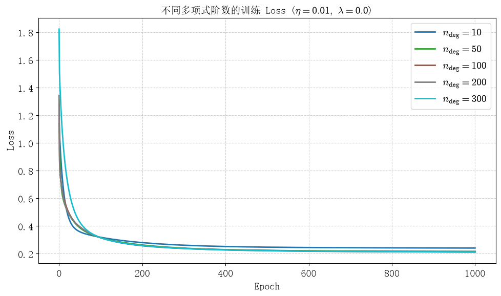

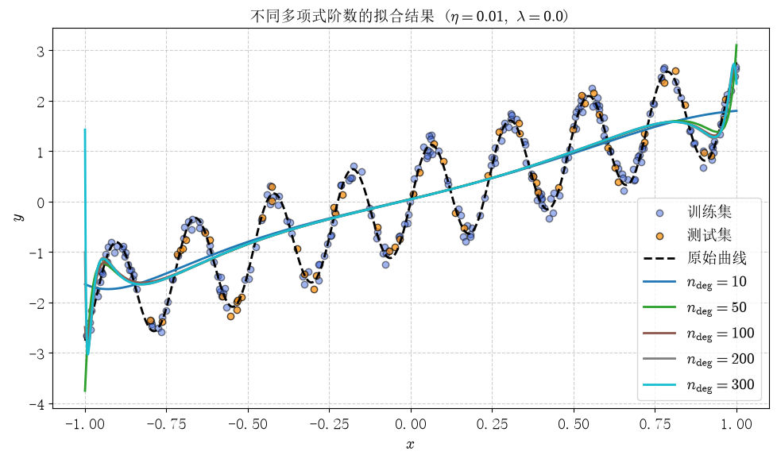

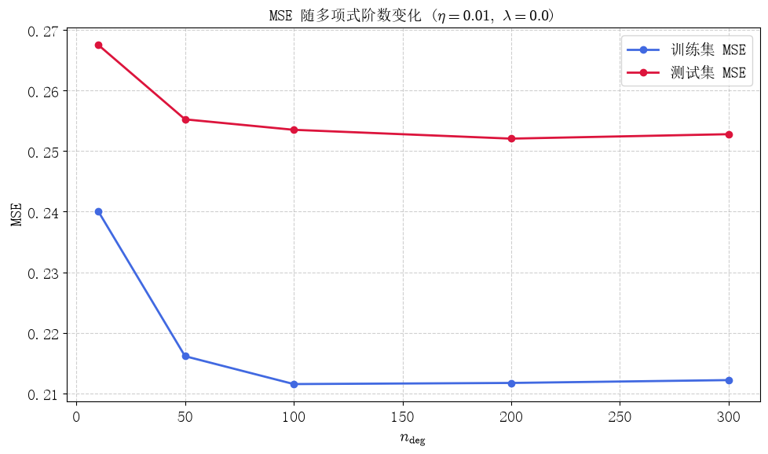

```python
degrees = [10, 50, 100, 200, 300]

fig_loss, fig_fit, fig_mse, results = compare_degrees(
    degrees,
    lr=0.01,
    lam=0.0,
    n_epochs=1000,
    title_suffix=r" ($\eta=0.01,\ \lambda=0.0$)",
)

display_inline(fig_loss)
display_inline(fig_fit)
display_inline(fig_mse)
```

表面上，这里随着多项式阶数 $n_{deg}$ 增大，系统的 MSE 减小，但是从不同多项式的拟合结果中，可以看到，随着系统的阶数增大，系统并没有抓住数据的振荡趋势.

同时，我们注意到，当 $n_{deg}=300$ 时，$n_{deg} > n$，也就是系统的阶数已经大于数据组的数量了，根据数学多项式拟合相关知识，我们可以知道，此时我们已经可以由数据直接得到能经过每一个点的拟合模型了. 但我们通过梯度下降仍旧欠拟合，这是需要解决的一个大的问题.

下面我们进一步从数据矩阵 $X$ 的数值性质分析产生这一现象的原因.

### 幂函数基底梯度下降失效的分析

对于幂函数基底

$$ 1,x,x^2,x^3,\dots,x^{n_{deg}}, $$

其对应的数据矩阵实际上是一个 Vandermonde 型矩阵. 我们观察数据矩阵的奇异值，判断其是否“病态”

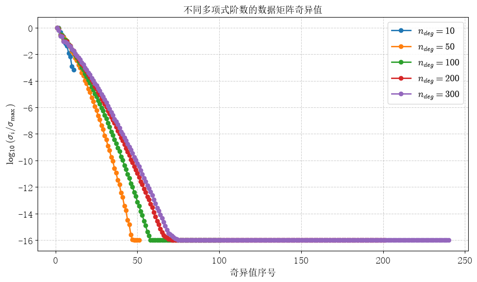

```python
degrees = [10, 50, 100, 200, 300]
fig, ax = plt.subplots(figsize=(10, 6))

for n_deg in degrees:
    X = np.vander(x_train, n_deg + 1, increasing=True)
    mean = X[:, 1:].mean(axis=0)
    std = X[:, 1:].std(axis=0)
    std[std < 1e-12] = 1.0
    X[:, 1:] = (X[:, 1:] - mean) / std
    s = np.linalg.svd(X, compute_uv=False)
    s_normalized = s / s[0]
    log_s = np.log10(np.maximum(s_normalized, 1e-16))
    ax.plot(
        np.arange(1, len(s) + 1),
        log_s,
        linewidth=2,
        marker="o",
        label=rf"$n_{{deg}}={n_deg}$"
    )

ax.set_title("不同多项式阶数的数据矩阵奇异值")
ax.set_xlabel("奇异值序号")
ax.set_ylabel(r"$\log_{10}(\sigma_i / \sigma_{\max})$")
ax.grid(True, linestyle="--", alpha=0.6)
ax.legend()

fig.tight_layout()
display_inline(fig)
```

可以看到，随着多项式阶数增大，数据矩阵中出现了越来越小的奇异值，并且不同奇异值之间的数量级差异迅速增大.

这说明高阶情况下数据矩阵 $X$ 的不同列逐渐接近线性相关. 实际上是由于幂函数基底并不是正交的，

前面进行的特征标准化只能使各列特征具有相近的尺度，但是不能消除不同特征之间的相关性. 因此，在普通幂函数基底下，高阶多项式对应的数据矩阵数值性质较差，使得梯度下降很难有效训练这些高阶特征.

因此，下面不再继续增加普通幂函数的阶数，而是改用正交多项式基底.

### 正交多项式基底

原先幂级数基底的一大问题，在于每一个基底之间不是**正交**的，一种直接的解决方法是将幂函数基底

$$ 1,x,x^2,\dots,x^n $$

进行正交化，由于本题数据定义域为 $[-1,1]$，并且 $x$ 采用均匀随机采样，因此这里选取在 $[-1,1]$ 上具有正交性的 **Legendre 多项式**：

$$ P_0(x),P_1(x),P_2(x),\dots,P_n(x). $$

由于每一个新基矢都是原先基矢的线性组合，因此更换为 Legendre 基底并没有提高模型理论上的表达能力，只是重新选择了一组数值性质更好的坐标基底.

下面仍然使用相同的梯度下降方法进行训练.

取 Legendre 多项式阶数 $50$.

```python
n_deg = 50

X_train = np.polynomial.legendre.legvander(x_train, n_deg)
X_test = np.polynomial.legendre.legvander(x_test, n_deg)
X_true = np.polynomial.legendre.legvander(x_true, n_deg)

mean, std = X_train[:, 1:].mean(axis=0), X_train[:, 1:].std(axis=0)
std[std < 1e-12] = 1.0

X_train[:, 1:] = (X_train[:, 1:] - mean) / std
X_test[:, 1:] = (X_test[:, 1:] - mean) / std
X_true[:, 1:] = (X_true[:, 1:] - mean) / std

w = np.random.normal(0, 0.1, n_deg+1)
```

```
Training: 1000/1000
```

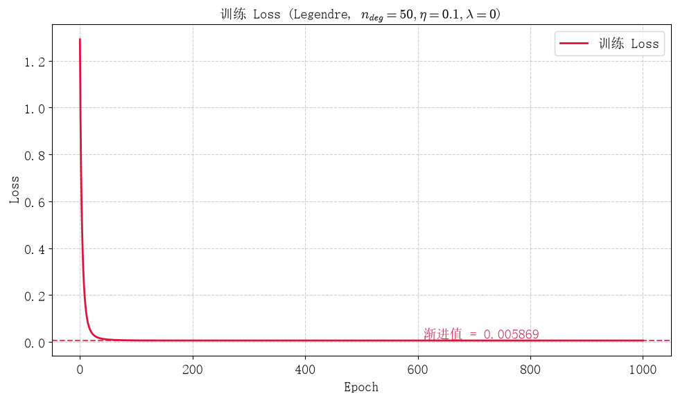

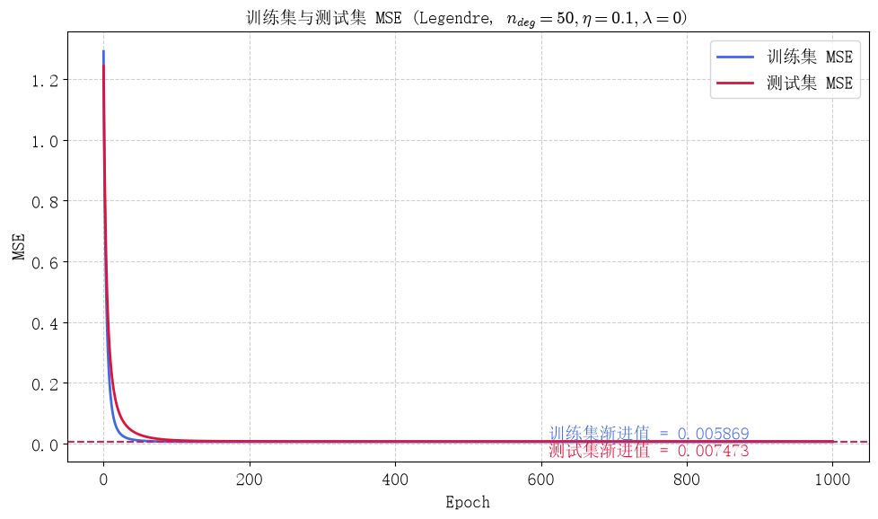

```python
lr, lam, n_epochs = 0.1, 0.0, 1000
w, loss_history, train_mse_history, test_mse_history = train(X_train, y_train, X_test, y_test, w, n_epochs, lr, lam)

fig_loss, fig_mse = plot_training_history(loss_history, train_mse_history, test_mse_history, r" (Legendre, $n_{deg}=50,\eta=0.1,\lambda=0$)")
display_inline(fig_loss)
display_inline(fig_mse)
```

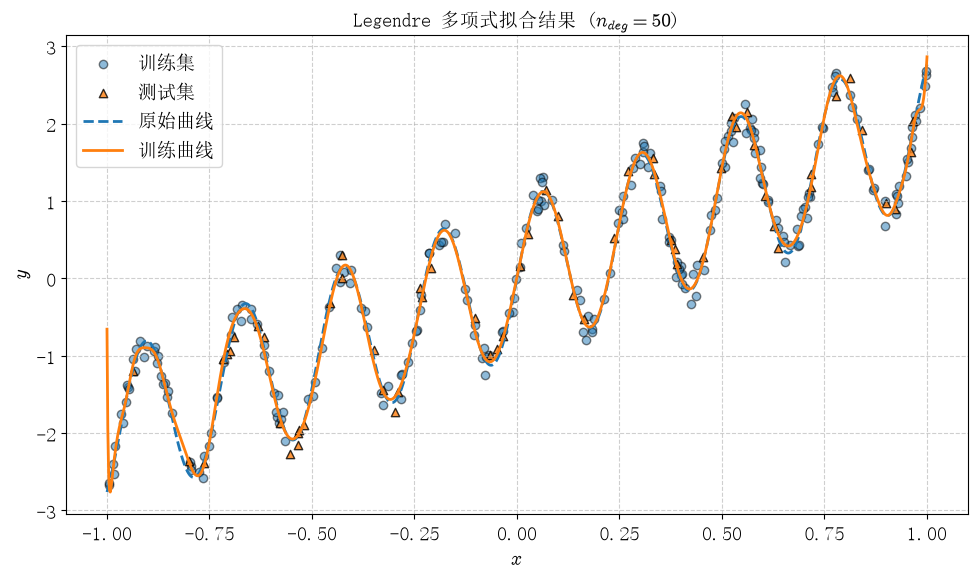

```python
y_pred = X_true @ w

fig, ax = plt.subplots(figsize=(10, 6))
ax.scatter(x_train, y_train, alpha=0.5, edgecolors="k", label="训练集")
ax.scatter(x_test, y_test, alpha=0.8, edgecolors="k", marker="^", label="测试集")
ax.plot(x_true, y_true, linestyle="--", linewidth=2, label="原始曲线")
ax.plot(x_true, y_pred, linewidth=2, label="训练曲线")
ax.set_title(r"Legendre 多项式拟合结果 ($n_{deg}=50$)")
ax.set_xlabel(r"$x$")
ax.set_ylabel(r"$y$")
ax.grid(True, linestyle="--", alpha=0.6)
ax.legend()
fig.tight_layout()
display_inline(fig)
```

可见，在使用 Legendre 多项式替换幂级数作为基底后，系统拟合程度有了显著提升.

下面进一步改变 Legendre 多项式的阶数，观察模型性能.

```python
degrees = [10, 50, 100, 150, 200]
results_legendre = {}

for n_deg in degrees:
    X_train = np.polynomial.legendre.legvander(x_train, n_deg); X_test = np.polynomial.legendre.legvander(x_test, n_deg); X_true = np.polynomial.legendre.legvander(x_true, n_deg)
    mean, std = X_train[:, 1:].mean(axis=0), X_train[:, 1:].std(axis=0); std[std < 1e-12] = 1.0
    X_train[:, 1:] = (X_train[:, 1:] - mean) / std; X_test[:, 1:] = (X_test[:, 1:] - mean) / std; X_true[:, 1:] = (X_true[:, 1:] - mean) / std
    w = np.random.default_rng(42).normal(0, 0.1, n_deg+1)
    w, loss, train_mse, test_mse = train(X_train, y_train, X_test, y_test, w, 1000, 0.1, 0.0)
    results_legendre[n_deg] = {"w": w, "loss": loss, "train_mse": train_mse, "test_mse": test_mse, "y_pred": X_true @ w}
```

```
Training: 1000/1000
Training: 1000/1000
Training: 1000/1000
Training: 1000/1000
Training: 1000/1000
```

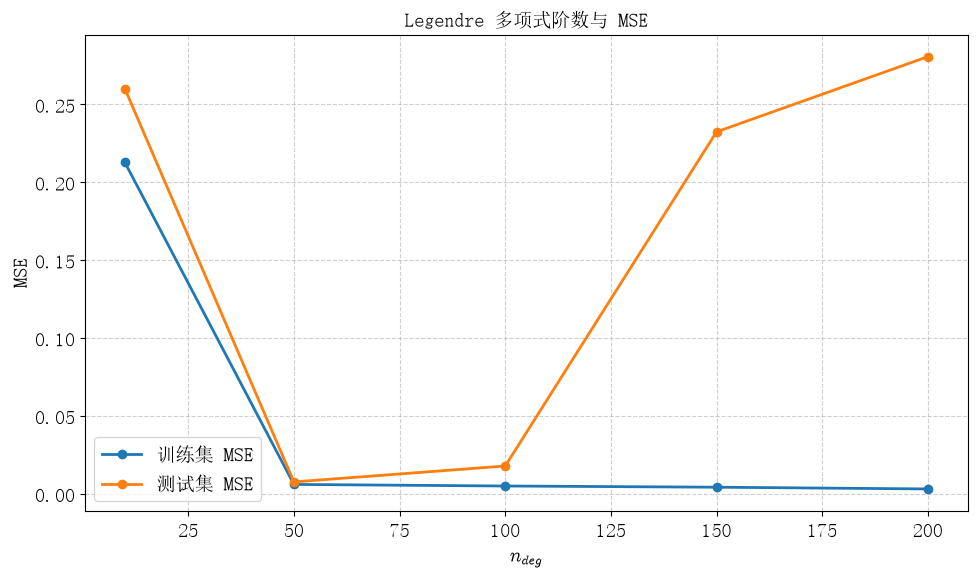

```python
train_mse = [results_legendre[n]["train_mse"][-1] for n in degrees]
test_mse = [results_legendre[n]["test_mse"][-1] for n in degrees]

fig, ax = plt.subplots(figsize=(10, 6))
ax.plot(degrees, train_mse, marker="o", linewidth=2, label="训练集 MSE")
ax.plot(degrees, test_mse, marker="o", linewidth=2, label="测试集 MSE")
ax.set_title("Legendre 多项式阶数与 MSE")
ax.set_xlabel(r"$n_{deg}$")
ax.set_ylabel("MSE")
ax.grid(True, linestyle="--", alpha=0.6)
ax.legend()
fig.tight_layout()
display_inline(fig)
```

从结果可以看到，当 $n_{deg}$ 较小时，模型仍然无法表示原函数中的快速振荡，因此存在明显欠拟合.

因此，对于本题的数据，约 $50$ 阶的 Legendre 多项式已经具有足够的表达能力.

同时这也说明，前面普通幂函数在 $n_{deg}=50,100$ 甚至更高阶时仍然无法正常拟合，并不是因为多项式的表达能力不足，而主要是由于普通幂函数基底在高阶时数值性质较差.

### 模型评估和最优模型选择

取最优的 $n_{deg}=50$ 的 Legendre 多项式模型.

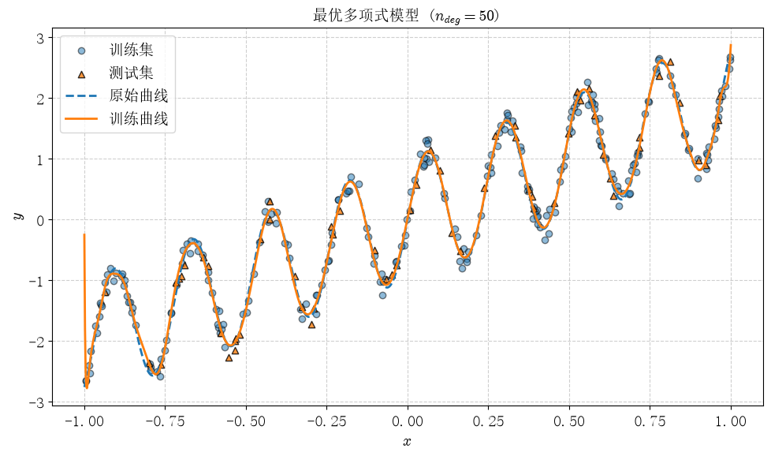

```python
n_deg = 50
result_poly = results_legendre[n_deg]

fig, ax = plt.subplots(figsize=(10, 6))
ax.scatter(x_train, y_train, alpha=0.5, edgecolors="k", label="训练集")
ax.scatter(x_test, y_test, alpha=0.8, edgecolors="k", marker="^", label="测试集")
ax.plot(x_true, y_true, linestyle="--", linewidth=2, label="原始曲线")
ax.plot(x_true, result_poly["y_pred"], linewidth=2, label="训练曲线")
ax.set_title(r"最优多项式模型 ($n_{deg}=50$)")
ax.set_xlabel(r"$x$")
ax.set_ylabel(r"$y$")
ax.grid(True, linestyle="--", alpha=0.6)
ax.legend()
fig.tight_layout()
display_inline(fig)
```

此时系统测试集 MSE 为：

```python
result_poly["test_mse"][-1]
```

$\displaystyle 0.00748120817411446$

## 使用正弦函数基底

### 特征工程

与前面的多项式基底类似，我们也可以使用正弦函数作为基函数，将原始的一维数据映射到更高维的特征空间.

这里构造正弦函数基底

$$ \phi_k(x)=\sin(kx),\qquad k=1,2,\dots,n_{\sin} $$

同时保留常数项，因此模型可以写为

$$ \hat y(x)=w_0+\sum_{k=1}^{n_{\sin}}w_k\sin(kx). $$

对应的特征矩阵为

$$ X= \begin{bmatrix} 1 & \sin x_1 & \sin 2x_1 & \cdots & \sin(n_{\sin}x_1)\\ 1 & \sin x_2 & \sin 2x_2 & \cdots & \sin(n_{\sin}x_2)\\ \vdots & \vdots & \vdots & \ddots & \vdots\\ 1 & \sin x_N & \sin 2x_N & \cdots & \sin(n_{\sin}x_N) \end{bmatrix}. $$

```python
def sine_features(x, n_sin):
    return np.column_stack([np.ones_like(x)] + [np.sin(k*x) for k in range(1, n_sin+1)])
```

同样，由于不同正弦特征的分布仍然存在一定差异，这里继续使用与前面相同的标准化方法.

### 模型构建与训练、超参优化

损失函数和梯度下降算法仍然使用前面定义的函数，不再重新定义.

为了观察正弦函数数量对模型的影响，固定

$$ \eta=0.1,\qquad \lambda=0,\qquad n_{epoch}=1000, $$

分别取

```python
orders = [10, 15, 20, 25, 30, 35, 40]
results_sine = {}

for n_sin in orders:
    X_train = sine_features(x_train, n_sin); X_test = sine_features(x_test, n_sin); X_true = sine_features(x_true, n_sin)
    mean, std = X_train[:, 1:].mean(axis=0), X_train[:, 1:].std(axis=0); std[std < 1e-12] = 1.0
    X_train[:, 1:] = (X_train[:, 1:] - mean) / std; X_test[:, 1:] = (X_test[:, 1:] - mean) / std; X_true[:, 1:] = (X_true[:, 1:] - mean) / std
    w = np.random.default_rng(42).normal(0, 0.1, n_sin+1)
    w, loss, train_mse, test_mse = train(X_train, y_train, X_test, y_test, w, 1000, 0.1, 0.0)
    results_sine[n_sin] = {"w": w, "mean": mean, "std": std, "loss": loss, "train_mse": train_mse, "test_mse": test_mse, "y_pred": X_true @ w}
```

```
Training: 1000/1000
Training: 1000/1000
Training: 1000/1000
Training: 1000/1000
Training: 1000/1000
Training: 1000/1000
Training: 1000/1000
```

观察 MSE 随 $n_{sin}$ 的变化：

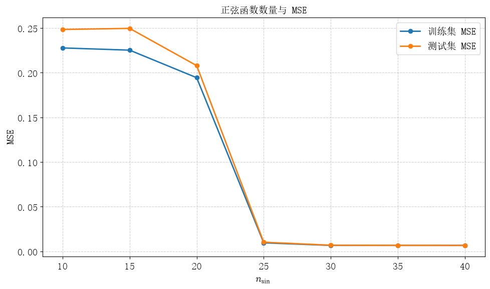

```python
train_mse = [results_sine[n]["train_mse"][-1] for n in orders]
test_mse = [results_sine[n]["test_mse"][-1] for n in orders]

fig, ax = plt.subplots(figsize=(10, 6))
ax.plot(orders, train_mse, marker="o", linewidth=2, label="训练集 MSE")
ax.plot(orders, test_mse, marker="o", linewidth=2, label="测试集 MSE")
ax.set_title("正弦函数数量与 MSE")
ax.set_xlabel(r"$n_{\sin}$"); ax.set_ylabel("MSE")
ax.grid(True, linestyle="--", alpha=0.6); ax.legend()
fig.tight_layout()
display_inline(fig)
```

可以看到，当 $n_{\sin}<25$ 时，模型中不存在与原函数振荡频率接近的基函数，因此仍然难以准确描述原始数据中的快速振荡.

当 $n_{\sin}\approx25$ 时，特征空间中出现接近 $\sin 26x$ 的项，因此模型对振荡部分的拟合能力出现明显提高.

我们也可以从模型的拟合结果中观察：

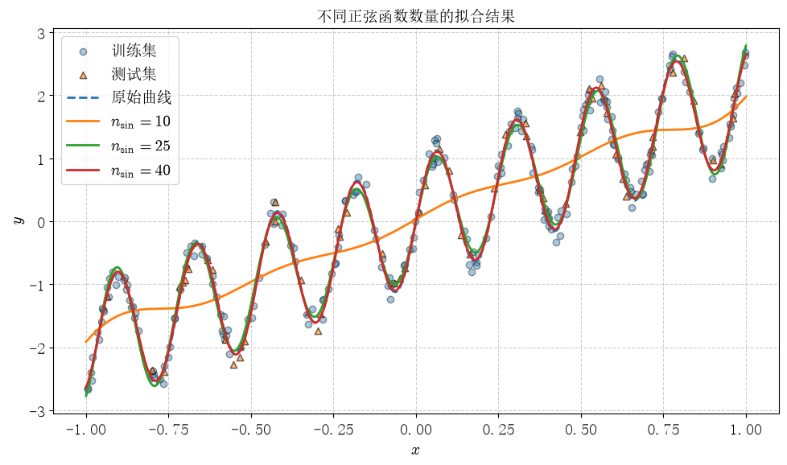

```python
fig, ax = plt.subplots(figsize=(10, 6))
ax.scatter(x_train, y_train, alpha=0.4, edgecolors="k", label="训练集")
ax.scatter(x_test, y_test, alpha=0.6, edgecolors="k", marker="^", label="测试集")
ax.plot(x_true, y_true, linestyle="--", linewidth=2, label="原始曲线")
for n_sin in [10, 25, 40]: ax.plot(x_true, results_sine[n_sin]["y_pred"], linewidth=2, label=rf"$n_{{\sin}}={n_sin}$")
ax.set_title("不同正弦函数数量的拟合结果")
ax.set_xlabel(r"$x$"); ax.set_ylabel(r"$y$")
ax.grid(True, linestyle="--", alpha=0.6); ax.legend()
fig.tight_layout()
display_inline(fig)
```

从拟合曲线中可以更加明显地观察到这一变化.

当 $n_{\sin}=10$ 时，模型基本无法恢复原函数中的快速振荡；当 $n_{\sin}=25$ 时，模型已经能够较好地学习振荡频率.

### 模型评估和最优模型选择

我们分析最优时的正弦函数阶数：

```python
orders[np.argmin(test_mse)]
```

$\displaystyle 40$

也就是，在前面的训练中，$n_{\sin}=40$ 时，系统的测试集 MSE 最小，我们选取其作为正弦函数基底模型.

此时，系统的测试集 MSE 为：

```python
test_mse[np.argmin(test_mse)]
```

$\displaystyle 0.0065333318049563$

## 混合基底

### 特征工程

前面分别使用多项式和正弦函数作为基底进行拟合. 从我们已知的数学角度，两种基底应该具有不同的特点：多项式比较适合描述数据整体的变化趋势，而正弦函数则更加适合描述其中的周期振荡.

因此，可以将两种基底组合起来，构造混合基底

$$ P_0(x),P_1(x),\dots,P_{n_{deg}}(x), \sin x,\sin2x,\dots,\sin(n_{\sin}x). $$

于是模型可以写为

$$ \sum_{j=0}^{n_{deg}}a_jP_j(x) + \sum_{k=1}^{n_{\sin}}b_k\sin(kx). $$

其中 $P_j(x)$ 为 Legendre 多项式.

这样预期可以分别使用多项式部分描述整体趋势，使用正弦函数部分描述周期变化.

数据矩阵构造代码如下，前 $n_{deg}$ 个特征为 $P_l$，后 $n_{\sin}$ 个特征对应 $\sin(kx)$ 同样进行标准化.

```python
@nb.njit(cache=True)
def mixed_features_nb(x, n_deg, n_sin):
    X = np.empty((len(x), n_deg+n_sin+1))
    X[:, 0] = 1.0

    if n_deg >= 1: X[:, 1] = x
    for n in range(2, n_deg+1):
        for i in range(len(x)): X[i, n] = ((2*n-1)*x[i]*X[i, n-1]-(n-1)*X[i, n-2])/n

    for k in range(1, n_sin+1):
        for i in range(len(x)): X[i, n_deg+k] = np.sin(k*x[i])

    return X


@nb.njit(cache=True)
def standardize_nb(X_train, X_test, X_true):
    for j in range(1, X_train.shape[1]):
        mean = 0.0
        for i in range(X_train.shape[0]): mean += X_train[i, j]
        mean /= X_train.shape[0]

        var = 0.0
        for i in range(X_train.shape[0]): var += (X_train[i, j]-mean)**2
        std = np.sqrt(var/X_train.shape[0])
        if std < 1e-12: std = 1.0

        for i in range(X_train.shape[0]): X_train[i, j] = (X_train[i, j]-mean)/std
        for i in range(X_test.shape[0]): X_test[i, j] = (X_test[i, j]-mean)/std
        for i in range(X_true.shape[0]): X_true[i, j] = (X_true[i, j]-mean)/std
```

### 模型构建与训练、超参优化

对于混合基底，此时模型同时受到两个参数影响：

$$ n_{deg},\qquad n_{\sin}. $$

因此不能再像前面一样只改变一个参数进行比较. 下面同时改变 $n_{deg}$ 和 $n_{\sin}$，对每一组参数分别进行训练，并记录最终测试集 MSE.

Loss Function 仍旧和之前相同，仍然固定

$$ \eta=0.1,\qquad\lambda=0,\qquad n_{epoch}=1000. $$

取

$$ n_{deg}=1,5,10,20,30,40,50 $$

以及

$$ n_{\sin}=5,10,15,20,25,26,30,35,40. $$

随后将 $n_{deg}$、$n_{\sin}$ 和测试集 MSE 同时绘制为三维曲面.

这里扫描量比较大，使用 numba 进行多线程计算.

```python
@nb.njit(cache=True)
def mse_nb(X, y, w):
    mse = 0.0
    for i in range(X.shape[0]):
        pred = 0.0
        for j in range(X.shape[1]): pred += X[i, j]*w[j]
        mse += (pred-y[i])**2
    return mse/(2*X.shape[0])


@nb.njit(cache=True)
def train_nb(X_train, y_train, X_test, y_test, w, n_epochs, lr, lam):
    loss = np.empty(n_epochs+1); train_mse = np.empty(n_epochs+1); test_mse = np.empty(n_epochs+1)
    train_mse[0] = mse_nb(X_train, y_train, w); test_mse[0] = mse_nb(X_test, y_test, w)
    loss[0] = train_mse[0] + 0.5*lam*np.sum(w*w)

    for epoch in range(1, n_epochs+1):
        grad = np.zeros(len(w))

        for i in range(X_train.shape[0]):
            pred = 0.0
            for j in range(X_train.shape[1]): pred += X_train[i, j]*w[j]
            err = pred-y_train[i]
            for j in range(X_train.shape[1]): grad[j] += X_train[i, j]*err

        for j in range(len(w)): w[j] -= lr*(grad[j]/X_train.shape[0] + lam*w[j])

        train_mse[epoch] = mse_nb(X_train, y_train, w); test_mse[epoch] = mse_nb(X_test, y_test, w)
        loss[epoch] = train_mse[epoch] + 0.5*lam*np.sum(w*w)

    return w, loss, train_mse, test_mse


@nb.njit(parallel=True, cache=True)
def scan_mixed_nb(x_train, y_train, x_test, y_test, x_true, degrees, orders, w_init, n_epochs, lr, lam):
    n_deg, n_sin = len(degrees), len(orders)
    n_tasks = n_deg*n_sin
    max_features = degrees[-1]+orders[-1]+1

    W = np.full((n_tasks, max_features), np.nan)
    loss_all = np.empty((n_tasks, n_epochs+1))
    train_mse_all = np.empty((n_tasks, n_epochs+1))
    test_mse_all = np.empty((n_tasks, n_epochs+1))
    y_pred_all = np.empty((n_tasks, len(x_true)))

    for idx in nb.prange(n_tasks):
        i, j = idx//n_deg, idx%n_deg
        ns, nd = orders[i], degrees[j]

        X_train = mixed_features_nb(x_train, nd, ns); X_test = mixed_features_nb(x_test, nd, ns); X_true = mixed_features_nb(x_true, nd, ns)
        standardize_nb(X_train, X_test, X_true)

        m = nd+ns+1
        w = w_init[:m].copy()
        w, loss, train_mse, test_mse = train_nb(X_train, y_train, X_test, y_test, w, n_epochs, lr, lam)

        W[idx, :m] = w
        loss_all[idx] = loss
        train_mse_all[idx] = train_mse
        test_mse_all[idx] = test_mse

        for k in range(len(x_true)):
            pred = 0.0
            for l in range(m): pred += X_true[k, l]*w[l]
            y_pred_all[idx, k] = pred

    return W, loss_all, train_mse_all, test_mse_all, y_pred_all
```

正式进行扫描：

```python
degrees = np.array([1, 5, 10, 20, 30, 40, 50], dtype=np.int64)
orders = np.array([5, 10, 15, 20, 25, 26, 30, 35, 40], dtype=np.int64)

max_features = degrees[-1]+orders[-1]+1
w_init = np.random.default_rng(42).normal(0, 0.1, max_features)

W, loss_all, train_mse_all, test_mse_all, y_pred_all = scan_mixed_nb(
    x_train, y_train, x_test, y_test, x_true,
    degrees, orders, w_init,
    1000, 0.1, 0.0
)

results_mixed = {}

for i, n_sin in enumerate(orders):
    for j, n_deg in enumerate(degrees):
        idx = i*len(degrees)+j
        m = n_deg+n_sin+1
        results_mixed[(int(n_deg), int(n_sin))] = {
            "w": W[idx, :m],
            "loss": loss_all[idx],
            "train_mse": train_mse_all[idx],
            "test_mse": test_mse_all[idx],
            "y_pred": y_pred_all[idx]
        }

test_mse_mixed = test_mse_all[:, -1].reshape(len(orders), len(degrees))
```

绘制图像：

```
最优 n_deg：10
最优 n_sin：30
测试集 MSE：0.0064534
```

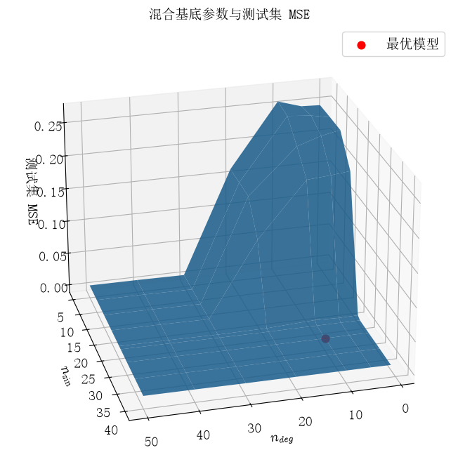

```python
best_idx = np.unravel_index(np.argmin(test_mse_mixed), test_mse_mixed.shape)
best_sin, best_deg = orders[best_idx[0]], degrees[best_idx[1]]
best_mse = test_mse_mixed[best_idx]

print(f"最优 n_deg：{best_deg}")
print(f"最优 n_sin：{best_sin}")
print(f"测试集 MSE：{best_mse:.6g}")

N_deg, N_sin = np.meshgrid(degrees, orders)

fig = plt.figure(figsize=(10, 7))
ax = fig.add_subplot(111, projection="3d")
ax.plot_surface(N_deg, N_sin, test_mse_mixed, alpha=0.85)
ax.scatter(best_deg, best_sin, best_mse, s=60, c="red", label="最优模型")
ax.set_xlabel(r"$n_{deg}$"); ax.set_ylabel(r"$n_{\sin}$"); ax.set_zlabel("测试集 MSE")
ax.set_title("混合基底参数与测试集 MSE")
ax.view_init(elev=25, azim=75)
ax.legend()
fig.tight_layout()
display_inline(fig)
```

在混合模型中，当 $n_{deg}=10$，$n_{\sin}=30$ 时，测试集 MSE 最小.

### 模型评估

取混合模型中，$n_{deg}=10$，$n_{\sin}=30$ 时作为最优模型. 此时系统的拟合结果为：

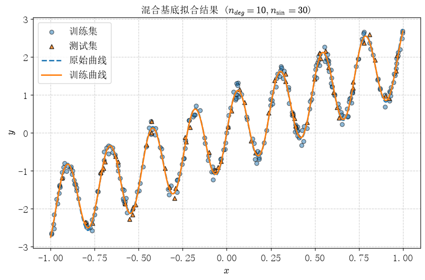

```python
result_mixed = results_mixed[(best_deg, best_sin)]

fig, ax = plt.subplots(figsize=(10, 6))
ax.scatter(x_train, y_train, alpha=0.5, edgecolors="k", label="训练集")
ax.scatter(x_test, y_test, alpha=0.8, edgecolors="k", marker="^", label="测试集")
ax.plot(x_true, y_true, linestyle="--", linewidth=2, label="原始曲线")
ax.plot(x_true, result_mixed["y_pred"], linewidth=2, label="训练曲线")
ax.set_title(rf"混合基底拟合结果 ($n_{{deg}}={best_deg},n_{{\sin}}={best_sin}$)")
ax.set_xlabel(r"$x$"); ax.set_ylabel(r"$y$")
ax.grid(True, linestyle="--", alpha=0.6); ax.legend()
#fig.tight_layout()
display_inline(fig)
```

从最终拟合结果可以看到，混合基底能够同时描述数据整体的线性变化趋势和其中的快速周期振荡.

此时系统指标：

```python
print(f"训练集 MSE：{result_mixed['train_mse'][-1]:.6g}")
print(f"测试集 MSE：{result_mixed['test_mse'][-1]:.6g}")
print(f"模型参数量：{best_deg + best_sin + 1}")
```

```
训练集 MSE：0.00649295
测试集 MSE：0.0064534
模型参数量：41
```

## 模型比较

最后将前面得到的模型按照基底拆分为四类进行比较：

1. 普通幂函数多项式基底；
2. Legendre 正交多项式基底；
3. 正弦函数基底；
4. Legendre 多项式与正弦函数组成的混合基底.

这里沿用前文各部分参数扫描中选取的模型结果. 对于普通幂函数基底，取多项式阶数扫描中测试集 MSE 最低的 $n_{\mathrm{deg}}=200$；其余三类模型均取前文已经选出的最优参数. 模型参数量均包含常数项.

| 模型 | 模型参数 | 模型参数量 | 训练集 MSE | 测试集 MSE |
| --- | --- | --- | --- | --- |
| 普通幂函数多项式 | $n_{\mathrm{deg}}=200$ | 201 | 0.211717 | 0.252063 |
| Legendre 多项式 | $n_{\mathrm{deg}}=50$ | 51 | 0.00587502 | 0.00748121 |
| 正弦函数基底 | $n_{\sin}=40$ | 41 | 0.00658427 | 0.00653333 |
| Legendre + 正弦混合基底 | $n_{\mathrm{deg}}=10,\ n_{\sin}=30$ | 41 | 0.00649295 | **0.00645340** |

从结果可以得到：

- 普通幂函数基底效果最差.即使增加到 $200$ 阶，其训练集和测试集 MSE 仍显著高于其他模型，并且拟合曲线无法正确恢复原函数中的快速振荡.
- Legendre 基底显著改善了多项式模型的可训练性.
- 正弦函数基底与目标函数的周期结构更匹配.
- 混合基底取得最低测试误差

因此，在本次实验扫描到的模型中，最终选择

$$ n_{\mathrm{deg}}=10,\qquad n_{\sin}=30 $$

的 Legendre + 正弦混合基底模型作为最优模型. 其最终指标为

$$ \mathrm{MSE}_{\mathrm{train}}=0.00649295, \quad \mathrm{MSE}_{\mathrm{test}}=0.00645340 $$

训练集与测试集误差非常接近，说明该模型在当前数据划分下不仅能够较好地拟合训练数据，同时具有较好的泛化能力.

## 结论

我们使用梯度下降，研究不同超参数下的幂级数基底、正弦基底、混合基底在给定数据集的拟合效果，得到如下结论：

- 分析了普通幂函数基底训练困难的数值原因. 普通幂函数构成 Vandermonde 型数据矩阵. 奇异值分析表明，随着阶数增加，不同奇异值之间的数量级差异迅速扩大，数据矩阵不同列逐渐接近线性相关. 特征标准化只能统一各列尺度，却不能消除列之间的相关性，因此高阶普通幂函数基底具有较差的数值条件，使梯度下降难以有效优化.
- 使用 Legendre 正交多项式能有效改善多项式模型. Legendre 多项式与普通幂函数多项式张成相同的多项式空间，但具有更好的正交性和数值性质. 扫描 $n_{\mathrm{deg}}=10,50,100,150,200$ 后发现，$n_{\mathrm{deg}}=50$ 已能够较好恢复原函数振荡，其训练集 MSE 为 $0.00587502$，测试集 MSE 为 $0.00748121$；继续增加阶数时训练误差下降而测试误差上升，出现过拟合.
- 构造并扫描了 Legendre + 正弦混合基底. 同时改变 $n_{\mathrm{deg}}$ 与 $n_{\sin}$，考察整体趋势特征与周期特征的组合. 结果表明，$n_{\mathrm{deg}}=10,\ n_{\sin}=30$ 时测试集 MSE 最低.
- 四类模型的比较说明，基底选择比单纯增加模型阶数更重要. 普通幂函数多项式即使使用大量参数仍受数值病态限制；Legendre 基底通过改善数值条件显著提高了多项式模型性能；正弦基底由于与目标函数的周期结构匹配，在更少参数下获得更低误差；混合基底进一步结合了两类特征的优势.

在本次实验扫描到的模型中，最终选择

$$ n_{\mathrm{deg}}=10,\qquad n_{\sin}=30 $$

的 Legendre + 正弦混合基底模型作为最优模型. 其最终指标为

$$ \mathrm{MSE}_{\mathrm{train}}=0.00649295, \quad \mathrm{MSE}_{\mathrm{test}}=0.00645340 $$

训练集与测试集误差非常接近，说明该模型在当前数据划分下不仅能够较好地拟合训练数据，同时具有较好的泛化能力.

## 参考资料以及 AI 使用声明

- 背景补充部分个人写出大体大纲，细节使用 Google Gemini 3.6 Flash 生成并进行人工核验和修改.
- 代码编写使用 Deepseek V4 Flash FIM 模式进行补全和生成（尤其是绘图相关函数，基本是直接生成），经过人工核验和运行验证.
- Matplotlib 中英文字体 fallback 异常的排查使用 Codex + GPT-6 Astro 辅助完成，包括构造独立测试环境、最小复现、问题定位以及修复方案分析，最终结果经过人工复现和核验.
- 文本和公式编写使用 Deepseek V4 Flash FIM 模式进行生成和补全，经过人工核验和修改.

## 致谢

- 暂无

## 附一：问题

- 题目要求“$\xi$ 为 $[-1,1]$ 区间均匀分布随机数，幅度自己指定” 存在矛盾，当指定 $\xi$ 为均匀分布且给定函数定义域后，随机数幅度已经定死为 $1$ （即上限 1，下限 -1） . 与“幅度自己指定”矛盾. 这里根据前一年课程经验，取“噪声来源于标准均匀分布，但可以给噪声乘上一个自定义的缩放幅度.” 的含义, 上面代码即这么实现.
- 绘图过程中发现 Matplotlib 在同时使用 Times New Roman 和 SimSun 进行中英文字体 fallback 时存在异常：部分配置下中文字符无法显示. 使用 Codex + GPT-6 Astro 在单独环境中进行验证排查，发现是新版 Matplotlib 的问题，相关 Issue：https://github.com/matplotlib/matplotlib/issues/32063. 本项目中暂时通过调整字体配置规避该问题.
- 前面对普通幂函数基底失效的分析主要通过数据矩阵的奇异值说明不同特征之间存在较强相关性，以及矩阵数值性质较差，但是这里只说明了数据矩阵存在问题，并没有进一步直观展示这种性质为什么会导致梯度下降困难. 一个更加直观的方法是绘制参数空间中的 Loss Function 高度图或等高线图，并将梯度下降过程的参数轨迹同时绘制在图中，当前模型的参数维度较高，无法直接绘制，需要首先将参数空间降维到二维. 考虑过利用 PCA 对梯度下降过程中参数 $w$ 的变化轨迹进行降维，再在二维投影平面中计算 Loss 并绘制高度图，但由于时间限制没有进一步实现.
- 这里当我们对幂级数进行正交化，得到正交基底作为新的特征函数的时候，正交的过程需要指定内积的定义，而内积的定义是有一定随意性的，选定不同的定义方式（比如选定不同的权函数）即可得到不同的正交基底（不同的特征多项式）. 那么，不同内积的选取是否对系统收敛性质有所影响？这是需要进行讨论的，受限于时间和精力没有进行进一步讨论.

## 附二：其他学习心得

暂无